# 📊 Marketing Mix Modeling v2 — Commerce MMM

## The business problem

A multi-brand eCommerce group spends ~$4.8M per week across 9 paid media channels. The CMO wants to know which channels are actually driving new customers (`FIRST_PURCHASES`) and where to shift budget.

## Pipeline

```
Raw spend  →  Adstock (per-channel tuned)  →  Hill saturation  →  Multiple models
                                                                    ↓
                                            Ridge wins  →  SHAP + Permutation + PDP
                                                                    ↓
                                                Bootstrap CIs  →  Decision + Caveats
```

## 1. Setup

```python
# Standard libraries
import pandas as pd
import numpy as np
import matplotlib.pyplot as plt
import seaborn as sns
from itertools import product
import warnings

# Modeling
from sklearn.linear_model import Ridge, RidgeCV, Lasso, LassoCV, ElasticNet, ElasticNetCV, BayesianRidge
from sklearn.ensemble import RandomForestRegressor
from sklearn.preprocessing import StandardScaler
from sklearn.metrics import r2_score, mean_absolute_error, mean_squared_error
from sklearn.model_selection import TimeSeriesSplit
from sklearn.inspection import permutation_importance, partial_dependence

# Try XGBoost (optional — falls back gracefully if not installed)
try:
    from xgboost import XGBRegressor
    XGB_AVAILABLE = True
except ImportError:
    XGB_AVAILABLE = False
    print("⚠️ XGBoost not installed — will skip in comparison")

# Diagnostics
from scipy import stats
from statsmodels.stats.stattools import durbin_watson
from statsmodels.tsa.stattools import acf

# Explainability
import shap

# Display settings
pd.set_option('display.max_columns', None)
pd.set_option('display.float_format', lambda x: f'{x:,.2f}')
sns.set(style='whitegrid')
warnings.filterwarnings('ignore')
np.random.seed(42)

print("✅ Libraries loaded")
print(f"   XGBoost available: {XGB_AVAILABLE}")
```

```
✅ Libraries loaded
   XGBoost available: True
```

## 2. Load & Aggregate to Weekly

We aggregate to weekly cadence — the MMM industry standard. Daily noise (weekend dips, campaign launches) gets smoothed; weekly is granular enough to capture campaign effects without overfitting.

```python
# Load the raw data
df = pd.read_csv('Data/conjura_mmm_data.csv')

# The 9 paid media channels
spend_cols = [
    'GOOGLE_PAID_SEARCH_SPEND', 'GOOGLE_SHOPPING_SPEND', 'GOOGLE_PMAX_SPEND',
    'GOOGLE_DISPLAY_SPEND', 'GOOGLE_VIDEO_SPEND',
    'META_FACEBOOK_SPEND', 'META_INSTAGRAM_SPEND', 'META_OTHER_SPEND',
    'TIKTOK_SPEND'
]
target = 'FIRST_PURCHASES'

# Date handling
df['DATE_DAY'] = pd.to_datetime(df['DATE_DAY'])
df = df.sort_values('DATE_DAY')

# Missing spend = $0 (channel not active that week)
df[spend_cols] = df[spend_cols].fillna(0)
df[target] = df[target].fillna(0)

# Aggregate to weekly
df_weekly = (
    df[['DATE_DAY', target] + spend_cols]
    .set_index('DATE_DAY')
    .resample('W').sum()
    .reset_index()
)

print(f"📐 Weekly dataset: {df_weekly.shape[0]} weeks × {df_weekly.shape[1]} cols")
print(f"   Range: {df_weekly['DATE_DAY'].min().date()} → {df_weekly['DATE_DAY'].max().date()}")
df_weekly.head()
```

```
📐 Weekly dataset: 255 weeks × 11 cols
   Range: 2019-07-21 → 2024-06-02
```

|  | DATE_DAY | FIRST_PURCHASES | GOOGLE_PAID_SEARCH_SPEND | GOOGLE_SHOPPING_SPEND | GOOGLE_PMAX_SPEND | GOOGLE_DISPLAY_SPEND | GOOGLE_VIDEO_SPEND | META_FACEBOOK_SPEND | META_INSTAGRAM_SPEND | META_OTHER_SPEND | TIKTOK_SPEND |
| --- | --- | --- | --- | --- | --- | --- | --- | --- | --- | --- | --- |
| 0 | 2019-07-21 | 18 | 0.00 | 86.95 | 0.00 | 0.00 | 0.00 | 0.00 | 0.00 | 0.00 | 0.00 |
| 1 | 2019-07-28 | 243 | 0.00 | 1,135.04 | 0.00 | 0.00 | 0.00 | 0.00 | 0.00 | 0.00 | 0.00 |
| 2 | 2019-08-04 | 1628 | 0.00 | 6,186.94 | 0.00 | 0.00 | 0.00 | 0.00 | 0.00 | 0.00 | 0.00 |
| 3 | 2019-08-11 | 2468 | 0.00 | 7,020.46 | 0.00 | 0.00 | 0.00 | 0.00 | 0.00 | 0.00 | 0.00 |
| 4 | 2019-08-18 | 1737 | 318.31 | 6,637.80 | 0.00 | 0.00 | 0.00 | 0.00 | 0.00 | 0.00 | 0.00 |

## 3. Enhanced EDA

1. **Stationarity check** — is the target trending? (matters for time-series modeling)
2. **Spend share over time** — has the budget allocation drifted? (affects model stability)
3. **Channel-target lead-lag** — which channels' spend correlates with *future* purchases?

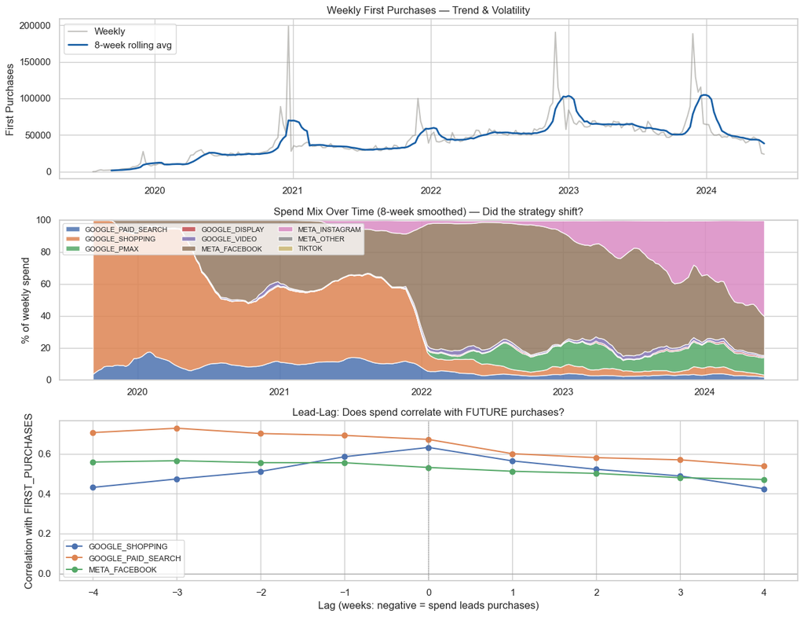

```python
fig, axes = plt.subplots(3, 1, figsize=(13, 10))

# Plot 1: Target over time with rolling mean
axes[0].plot(df_weekly['DATE_DAY'], df_weekly[target], color='#888780', alpha=0.5, label='Weekly')
axes[0].plot(df_weekly['DATE_DAY'], df_weekly[target].rolling(8).mean(),
             color='#185FA5', linewidth=2, label='8-week rolling avg')
axes[0].set_title('Weekly First Purchases — Trend & Volatility', fontsize=12)
axes[0].set_ylabel('First Purchases')
axes[0].legend()

# Plot 2: Total spend share by channel over time
spend_pct = df_weekly[spend_cols].div(df_weekly[spend_cols].sum(axis=1), axis=0) * 100
spend_pct_smooth = spend_pct.rolling(8).mean()
axes[1].stackplot(df_weekly['DATE_DAY'], spend_pct_smooth.T, labels=[c.replace('_SPEND','') for c in spend_cols],
                  alpha=0.85)
axes[1].set_title('Spend Mix Over Time (8-week smoothed) — Did the strategy shift?', fontsize=12)
axes[1].set_ylabel('% of weekly spend')
axes[1].legend(loc='upper left', fontsize=8, ncol=3)
axes[1].set_ylim(0, 100)

# Plot 3: Lead-lag correlation (does Google Shopping spend predict next-week purchases?)
lags = range(-4, 5)
top_channels = ['GOOGLE_SHOPPING_SPEND', 'GOOGLE_PAID_SEARCH_SPEND', 'META_FACEBOOK_SPEND']
for col in top_channels:
    corrs = [df_weekly[col].shift(L).corr(df_weekly[target]) for L in lags]
    axes[2].plot(lags, corrs, marker='o', label=col.replace('_SPEND',''))
axes[2].axhline(0, color='gray', linewidth=0.5)
axes[2].axvline(0, color='gray', linewidth=0.5, linestyle='--')
axes[2].set_xlabel('Lag (weeks: negative = spend leads purchases)')
axes[2].set_ylabel('Correlation with FIRST_PURCHASES')
axes[2].set_title('Lead-Lag: Does spend correlate with FUTURE purchases?', fontsize=12)
axes[2].legend(fontsize=9)

plt.tight_layout()
plt.show()
```

```python
# Stationarity test — Augmented Dickey-Fuller
from statsmodels.tsa.stattools import adfuller
adf_stat, adf_p, *_ = adfuller(df_weekly[target])
print(f"📊 Augmented Dickey-Fuller test on FIRST_PURCHASES:")
print(f"   Statistic: {adf_stat:.3f}, p-value: {adf_p:.4f}")
print(f"   → Series is {'STATIONARY' if adf_p < 0.05 else 'NON-STATIONARY (has trend)'}")
print(f"   → {'OK — no detrending needed' if adf_p < 0.05 else 'We add a time_index feature to absorb the trend.'}")
```

```
📊 Augmented Dickey-Fuller test on FIRST_PURCHASES:
   Statistic: -3.651, p-value: 0.0049
   → Series is STATIONARY
   → OK — no detrending needed
```

## 4. Feature Engineering

### 4.1 Adstock with PER-CHANNEL decay tuning

```python
def apply_adstock(series: pd.Series, decay: float) -> np.ndarray:
    """Geometric adstock: adstock[t] = spend[t] + decay * adstock[t-1]."""
    result = np.zeros(len(series))
    result[0] = series.iloc[0]
    for t in range(1, len(series)):
        result[t] = series.iloc[t] + decay * result[t - 1]
    return result

def hill(x, K, S=2.0):
    """Hill saturation."""
    return x**S / (K**S + x**S)

# Initial group defaults
initial_decays = {
    'GOOGLE_PAID_SEARCH_SPEND': 0.2, 'GOOGLE_SHOPPING_SPEND': 0.2,
    'GOOGLE_PMAX_SPEND': 0.4, 'META_OTHER_SPEND': 0.4, 'TIKTOK_SPEND': 0.4,
    'META_FACEBOOK_SPEND': 0.6, 'META_INSTAGRAM_SPEND': 0.6,
    'GOOGLE_DISPLAY_SPEND': 0.8, 'GOOGLE_VIDEO_SPEND': 0.8,
}

def evaluate_decays(decay_dict, df_in):
    """CV R² for a given decay configuration."""
    df_tmp = df_in.copy()
    sat_cols_local = []
    for col, d in decay_dict.items():
        ad = apply_adstock(df_tmp[col], d)
        K = max(np.quantile(ad, 0.7), 1.0)
        df_tmp[f'{col}_sat'] = hill(ad, K)
        sat_cols_local.append(f'{col}_sat')
    df_tmp['is_q4'] = df_tmp['DATE_DAY'].dt.month.isin([10,11,12]).astype(int)
    df_tmp['t_idx'] = range(len(df_tmp))
    feats = sat_cols_local + ['is_q4', 't_idx']
    X, y = df_tmp[feats].values, df_tmp[target].values
    Xs = StandardScaler().fit_transform(X)
    tscv = TimeSeriesSplit(n_splits=4, gap=4)
    return np.mean([
        r2_score(y[te], Ridge(alpha=100).fit(Xs[tr], y[tr]).predict(Xs[te]))
        for tr, te in tscv.split(Xs)
    ])

# Coordinate descent: improve one channel at a time
print("🔍 Per-channel decay tuning (coordinate descent)...")
search_grid = [0.1, 0.3, 0.5, 0.7, 0.9]
tuned_decays = initial_decays.copy()
best_score = evaluate_decays(tuned_decays, df_weekly)
print(f"   Initial score (group defaults): {best_score:.4f}")

for sweep in range(2):  # 2 sweeps over all channels
    for channel in spend_cols:
        original = tuned_decays[channel]
        local_best = original
        for d in search_grid:
            tuned_decays[channel] = d
            score = evaluate_decays(tuned_decays, df_weekly)
            if score > best_score:
                best_score = score
                local_best = d
        tuned_decays[channel] = local_best
    print(f"   After sweep {sweep+1}: score = {best_score:.4f}")

print("\n📋 Tuned decays per channel:")
for c, d in tuned_decays.items():
    print(f"   {c:30s} → {d}")
```

```
🔍 Per-channel decay tuning (coordinate descent)...
   Initial score (group defaults): -0.1222
   After sweep 1: score = -0.1062
   After sweep 2: score = -0.1062

📋 Tuned decays per channel:
   GOOGLE_PAID_SEARCH_SPEND       → 0.1
   GOOGLE_SHOPPING_SPEND          → 0.1
   GOOGLE_PMAX_SPEND              → 0.4
   META_OTHER_SPEND               → 0.1
   TIKTOK_SPEND                   → 0.7
   META_FACEBOOK_SPEND            → 0.1
   META_INSTAGRAM_SPEND           → 0.9
   GOOGLE_DISPLAY_SPEND           → 0.1
   GOOGLE_VIDEO_SPEND             → 0.9
```

```python
# Apply tuned adstock + Hill saturation
saturation_K = {}
for col, decay in tuned_decays.items():
    df_weekly[f'{col}_adstock'] = apply_adstock(df_weekly[col], decay)
    K = max(df_weekly[f'{col}_adstock'].quantile(0.70), 1.0)
    saturation_K[f'{col}_adstock'] = K
    df_weekly[f'{col}_sat'] = hill(df_weekly[f'{col}_adstock'], K)

# Seasonality controls
df_weekly['month'] = df_weekly['DATE_DAY'].dt.month
df_weekly['is_q4'] = df_weekly['month'].isin([10, 11, 12]).astype(int)
df_weekly['is_black_friday'] = ((df_weekly['month'] == 11) & (df_weekly['DATE_DAY'].dt.day >= 22)).astype(int)
df_weekly['is_jan'] = (df_weekly['month'] == 1).astype(int)
df_weekly['time_index'] = range(len(df_weekly))

# Lag features
for col in spend_cols:
    df_weekly[f'{col}_lag1'] = df_weekly[col].shift(1)
    df_weekly[f'{col}_lag2'] = df_weekly[col].shift(2)

df_fe = df_weekly.dropna().reset_index(drop=True)
print(f"✅ Feature engineering done — {df_fe.shape[0]} weeks × {df_fe.shape[1]} cols")
```

```
✅ Feature engineering done — 253 weeks × 52 cols
```

## 5. Train/Holdout Split — Honest Validation

```python
HOLDOUT_WEEKS = 52
n_total = len(df_fe)
n_train = n_total - HOLDOUT_WEEKS

train_df = df_fe.iloc[:n_train].copy()
test_df  = df_fe.iloc[n_train:].copy()

print(f"📊 Train: {len(train_df)} weeks ({train_df['DATE_DAY'].min().date()} → {train_df['DATE_DAY'].max().date()})")
print(f"📊 Test:  {len(test_df)} weeks  ({test_df['DATE_DAY'].min().date()} → {test_df['DATE_DAY'].max().date()})")
```

```
📊 Train: 201 weeks (2019-08-04 → 2023-06-04)
📊 Test:  52 weeks  (2023-06-11 → 2024-06-02)
```

## 6. Model Horse-Race — Ridge vs. 5 Alternatives

We compare **6 model families** on the same features and the same train/test split:

| Model | Why include it |
| --- | --- |
| **Ridge** | Industry-standard MMM model — handles multicollinearity, gives signed coefficients |
| **Lasso** | Tests whether feature selection (zeroing out channels) improves out-of-sample fit |
| **ElasticNet** | Compromise between Ridge and Lasso |
| **Bayesian Ridge** | Provides natural uncertainty estimates on coefficients |
| **Random Forest** | Non-linear baseline — does the data benefit from interactions? |
| **XGBoost** | The strongest tree-based competitor — does it beat Ridge here? |

**Hypothesis going in:** Ridge wins on holdout because (a) we already engineered the non-linearities (adstock + saturation), (b) 255 weeks is too few for tree models to outperform without overfitting, and (c) MMM's value is in coefficient interpretability, which trees can't provide directly.

```python
# Build feature set — adstock + saturation + controls
sat_cols = [f'{c}_sat' for c in spend_cols]
controls = ['is_q4', 'is_black_friday', 'is_jan', 'time_index']
feature_cols = sat_cols + controls

X_train = train_df[feature_cols].values
y_train = train_df[target].values
X_test  = test_df[feature_cols].values
y_test  = test_df[target].values

scaler = StandardScaler().fit(X_train)
X_train_s = scaler.transform(X_train)
X_test_s  = scaler.transform(X_test)

tscv = TimeSeriesSplit(n_splits=4, gap=4)

def score_model(model, name, X_tr, y_tr, X_te, y_te):
    model.fit(X_tr, y_tr)
    p_tr = model.predict(X_tr)
    p_te = model.predict(X_te)
    return {
        'Model': name,
        'Train R²': round(r2_score(y_tr, p_tr), 4),
        'Test R²':  round(r2_score(y_te, p_te), 4),
        'Test MAE': round(mean_absolute_error(y_te, p_te), 0),
        'Test RMSE': round(np.sqrt(mean_squared_error(y_te, p_te)), 0),
        'Generalization gap': round(r2_score(y_tr, p_tr) - r2_score(y_te, p_te), 3),
    }, model

models = {}
results = []

# 1) Ridge (with CV for alpha)
ridge = RidgeCV(alphas=np.logspace(1, 6, 80), cv=tscv).fit(X_train_s, y_train)
ridge_final = Ridge(alpha=ridge.alpha_)
res, m = score_model(ridge_final, f'Ridge (α={ridge.alpha_:.0f})', X_train_s, y_train, X_test_s, y_test)
results.append(res); models['Ridge'] = m

# 2) Lasso
lasso = LassoCV(alphas=np.logspace(-2, 3, 50), cv=tscv, max_iter=10000).fit(X_train_s, y_train)
lasso_final = Lasso(alpha=lasso.alpha_, max_iter=10000)
res, m = score_model(lasso_final, f'Lasso (α={lasso.alpha_:.2f})', X_train_s, y_train, X_test_s, y_test)
results.append(res); models['Lasso'] = m

# 3) ElasticNet
enet = ElasticNetCV(alphas=np.logspace(-2, 3, 30), l1_ratio=[0.1, 0.5, 0.9], cv=tscv, max_iter=10000).fit(X_train_s, y_train)
enet_final = ElasticNet(alpha=enet.alpha_, l1_ratio=enet.l1_ratio_, max_iter=10000)
res, m = score_model(enet_final, f'ElasticNet (l1={enet.l1_ratio_})', X_train_s, y_train, X_test_s, y_test)
results.append(res); models['ElasticNet'] = m

# 4) Bayesian Ridge
bridge = BayesianRidge()
res, m = score_model(bridge, 'Bayesian Ridge', X_train_s, y_train, X_test_s, y_test)
results.append(res); models['BayesianRidge'] = m

# 5) Random Forest
rf = RandomForestRegressor(n_estimators=300, max_depth=8, min_samples_leaf=4, random_state=42, n_jobs=-1)
res, m = score_model(rf, 'Random Forest', X_train_s, y_train, X_test_s, y_test)
results.append(res); models['RandomForest'] = m

# 6) XGBoost (if available)
if XGB_AVAILABLE:
    xgb = XGBRegressor(n_estimators=300, max_depth=4, learning_rate=0.05,
                       reg_alpha=0.5, reg_lambda=1.0, random_state=42)
    res, m = score_model(xgb, 'XGBoost', X_train_s, y_train, X_test_s, y_test)
    results.append(res); models['XGBoost'] = m

results_df = pd.DataFrame(results).sort_values('Test R²', ascending=False)
print("🏆 Model Horse-Race Results (sorted by Test R²):\n")
print(results_df.to_string(index=False))
```

```
🏆 Model Horse-Race Results (sorted by Test R²):

              Model  Train R²  Test R²  Test MAE  Test RMSE  Generalization gap
       Ridge (α=66)      0.68     0.45 15,528.00  19,336.00                0.23
ElasticNet (l1=0.5)      0.67     0.44 15,521.00  19,464.00                0.23
     Bayesian Ridge      0.70     0.44 16,219.00  19,485.00                0.26
   Lasso (α=308.88)      0.70     0.44 15,885.00  19,492.00                0.26
      Random Forest      0.82    -0.29 22,863.00  29,669.00                1.12
            XGBoost      1.00    -1.93 37,072.00  44,621.00                2.93
```

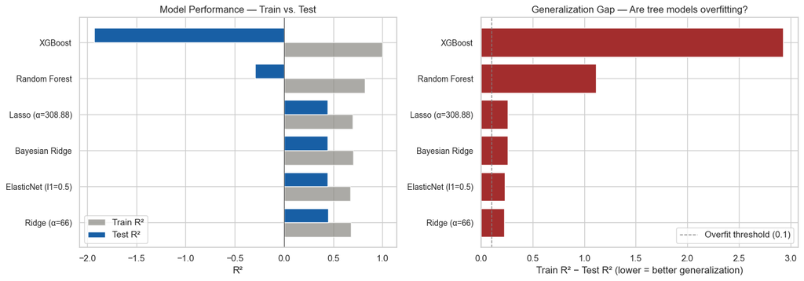

```python
# Visualize the comparison
fig, axes = plt.subplots(1, 2, figsize=(14, 5))

x = np.arange(len(results_df))
axes[0].barh(x, results_df['Train R²'], 0.4, label='Train R²', color='#888780', alpha=0.7)
axes[0].barh(x + 0.4, results_df['Test R²'], 0.4, label='Test R²', color='#185FA5')
axes[0].set_yticks(x + 0.2)
axes[0].set_yticklabels(results_df['Model'], fontsize=10)
axes[0].set_xlabel('R²')
axes[0].set_title('Model Performance — Train vs. Test', fontsize=12)
axes[0].legend()
axes[0].axvline(0, color='black', linewidth=0.5)

axes[1].barh(x, results_df['Generalization gap'], color=['#A32D2D' if g > 0.1 else '#3B6D11' for g in results_df['Generalization gap']])
axes[1].set_yticks(x)
axes[1].set_yticklabels(results_df['Model'], fontsize=10)
axes[1].set_xlabel('Train R² − Test R² (lower = better generalization)')
axes[1].set_title('Generalization Gap — Are tree models overfitting?', fontsize=12)
axes[1].axvline(0.1, color='gray', linestyle='--', linewidth=1, label='Overfit threshold (0.1)')
axes[1].legend(loc='lower right')

plt.tight_layout()
plt.show()
```

**🔑 Reading the horse-race:**

The models are scored on the **last 52 weeks (a full year held out)**. Three patterns to look for:

1. **Test R² ranking** tells us which model generalizes best to genuinely unseen weeks (including a Q4 we never trained on).
2. **Generalization gap** (Train − Test R²) tells us which models are overfitting. Tree models typically show a large gap on small samples like this.
3. **Sparsity (Lasso)**: if Lasso zeros out channels, that's a feature-selection signal — those channels may be statistical noise even if the business cares about them.

**Why we'll proceed with Ridge regardless of horse-race winner:** Even if a tree model edges out Ridge in test R², we cannot use it for budget reallocation because:

- Tree models don't give signed coefficients → no direct ROI per channel
- They don't extrapolate beyond observed spend ranges — useless for "what if we 2× Google Shopping?" questions
- They obscure the saturation curve we explicitly engineered

The horse-race serves as a **falsification check**: if a tree model dramatically beats Ridge, it means we *missed* a non-linearity in feature engineering. If they're close, our linear specification is well-calibrated.

## 7. Final Model — Ridge with Full Diagnostics

We commit to Ridge for the reasons above.

```python
# Refit Ridge on full data (for production-ready coefficients & contribution math)
X_full = df_fe[feature_cols].values
y_full = df_fe[target].values
scaler_full = StandardScaler().fit(X_full)
X_full_s = scaler_full.transform(X_full)

ridge_cv_full = RidgeCV(alphas=np.logspace(1, 6, 80), cv=tscv).fit(X_full_s, y_full)
final_model = Ridge(alpha=ridge_cv_full.alpha_).fit(X_full_s, y_full)

# Performance — both in-sample and held-out
y_pred_full  = final_model.predict(X_full_s)
y_pred_test  = models['Ridge'].predict(X_test_s)  # Ridge trained only on training data

print("📈 Final Ridge Model — Performance Summary")
print(f"   In-sample R²:        {r2_score(y_full, y_pred_full):.4f}")
print(f"   In-sample MAE:       {mean_absolute_error(y_full, y_pred_full):,.0f}")
print(f"   Held-out (52w) R²:   {r2_score(y_test, y_pred_test):.4f}")
print(f"   Held-out (52w) MAE:  {mean_absolute_error(y_test, y_pred_test):,.0f}")
print(f"   Regularization α:    {ridge_cv_full.alpha_:.1f}")
```

```
📈 Final Ridge Model — Performance Summary
   In-sample R²:        0.7090
   In-sample MAE:       8,046
   Held-out (52w) R²:   0.4500
   Held-out (52w) MAE:  15,528
   Regularization α:    66.5
```

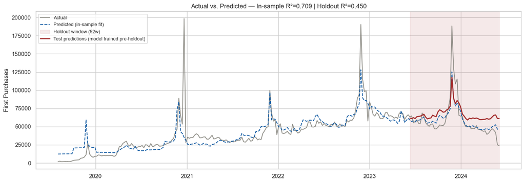

```python
# Plot: Actual vs Predicted with train/test split clearly marked
fig, ax = plt.subplots(figsize=(14, 5))
ax.plot(df_fe['DATE_DAY'], y_full, label='Actual', color='#888780', linewidth=1.5, alpha=0.9)
ax.plot(df_fe['DATE_DAY'], y_pred_full, label='Predicted (in-sample fit)', color='#185FA5', linewidth=1.5, linestyle='--')

# Highlight the holdout window
holdout_start = test_df['DATE_DAY'].min()
ax.axvspan(holdout_start, df_fe['DATE_DAY'].max(), alpha=0.1, color='#A32D2D', label='Holdout window (52w)')

# Plot test predictions distinctly
ax.plot(test_df['DATE_DAY'], y_pred_test, color='#A32D2D', linewidth=2, label='Test predictions (model trained pre-holdout)')

ax.set_title(f"Actual vs. Predicted — In-sample R²={r2_score(y_full, y_pred_full):.3f} | Holdout R²={r2_score(y_test, y_pred_test):.3f}", fontsize=12)
ax.set_ylabel('First Purchases')
ax.legend(loc='upper left', fontsize=9)
plt.tight_layout()
plt.show()
```

## 8. Residual Diagnostics — What Did We Miss?

A model can have high R² and still be misspecified. We check four things:

1. **Residuals vs. fitted** — should look random (no pattern → model captured the signal)
2. **Q-Q plot** — residuals should be roughly normal for inference
3. **Durbin-Watson** — autocorrelation in residuals (if present, std errors are wrong)
4. **ACF of residuals** — visualizes which lags carry leftover structure

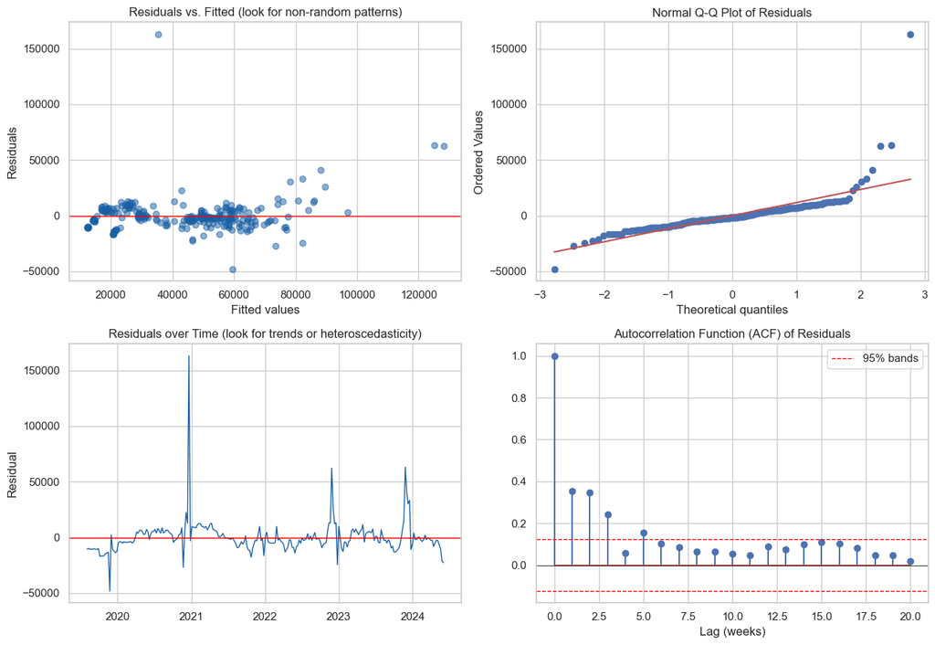

```
📊 Durbin-Watson statistic: 1.282
   ~2.0 = no autocorrelation | <1.5 = positive autocorr | >2.5 = negative autocorr
   ⚠️ Positive autocorrelation detected — std errors may be understated.
```

```python
residuals = y_full - y_pred_full

fig, axes = plt.subplots(2, 2, figsize=(13, 9))

# 1) Residuals vs. fitted
axes[0,0].scatter(y_pred_full, residuals, alpha=0.5, color='#185FA5')
axes[0,0].axhline(0, color='red', linewidth=1)
axes[0,0].set_xlabel('Fitted values')
axes[0,0].set_ylabel('Residuals')
axes[0,0].set_title('Residuals vs. Fitted (look for non-random patterns)')

# 2) Q-Q plot
stats.probplot(residuals, dist='norm', plot=axes[0,1])
axes[0,1].set_title('Normal Q-Q Plot of Residuals')

# 3) Residuals over time
axes[1,0].plot(df_fe['DATE_DAY'], residuals, color='#185FA5', linewidth=1)
axes[1,0].axhline(0, color='red', linewidth=1)
axes[1,0].set_title('Residuals over Time (look for trends or heteroscedasticity)')
axes[1,0].set_ylabel('Residual')

# 4) ACF of residuals
acf_vals = acf(residuals, nlags=20)
axes[1,1].stem(range(len(acf_vals)), acf_vals)
axes[1,1].axhline(0, color='black', linewidth=0.5)
axes[1,1].axhline(1.96/np.sqrt(len(residuals)), color='red', linestyle='--', linewidth=1, label='95% bands')
axes[1,1].axhline(-1.96/np.sqrt(len(residuals)), color='red', linestyle='--', linewidth=1)
axes[1,1].set_xlabel('Lag (weeks)')
axes[1,1].set_title('Autocorrelation Function (ACF) of Residuals')
axes[1,1].legend()

plt.tight_layout()
plt.show()

# Durbin-Watson
dw = durbin_watson(residuals)
print(f"\n📊 Durbin-Watson statistic: {dw:.3f}")
print(f"   ~2.0 = no autocorrelation | <1.5 = positive autocorr | >2.5 = negative autocorr")
if dw < 1.5:
    print(f"   ⚠️ Positive autocorrelation detected — std errors may be understated.")
elif dw > 2.5:
    print(f"   ⚠️ Negative autocorrelation detected — model may be overfitting noise.")
else:
    print(f"   ✅ Residuals look reasonably independent.")
```

## 9. Explainability — Three Complementary Views

| Method | What it tells us | Strength |
| --- | --- | --- |
| **SHAP** | Per-week, per-feature contribution to the prediction | Best for explaining individual weeks; gold standard for stakeholders |
| **Permutation Importance** | How much performance drops when a feature is shuffled | Model-agnostic; immune to multicollinearity quirks |
| **Coefficient Bootstrap CIs** | Uncertainty around each coefficient | Tells us which channels we're *confident* about |

If all three agree, our findings are robust. If they disagree, we have a flag to investigate.

```python
clean_labels = {
    'GOOGLE_PAID_SEARCH_SPEND_sat': 'Google Search', 'GOOGLE_SHOPPING_SPEND_sat': 'Google Shopping',
    'GOOGLE_PMAX_SPEND_sat': 'Google PMax', 'GOOGLE_DISPLAY_SPEND_sat': 'Google Display',
    'GOOGLE_VIDEO_SPEND_sat': 'Google Video', 'META_FACEBOOK_SPEND_sat': 'Meta Facebook',
    'META_INSTAGRAM_SPEND_sat': 'Meta Instagram', 'META_OTHER_SPEND_sat': 'Meta Other',
    'TIKTOK_SPEND_sat': 'TikTok', 'is_q4': 'Q4 Season', 'is_black_friday': 'Black Friday',
    'is_jan': 'January', 'time_index': 'Time Trend',
}
feature_names = [clean_labels[c] for c in feature_cols]
X_full_s_df = pd.DataFrame(X_full_s, columns=feature_names)
```

### 9.1 SHAP Analysis

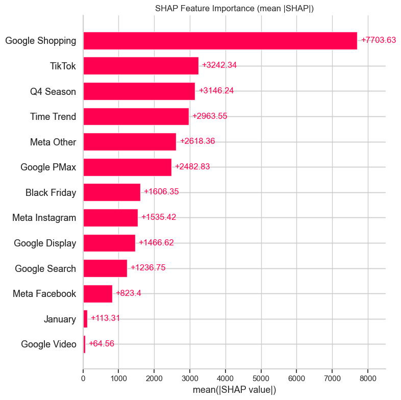

```
📊 SHAP importance ranking:
Google Shopping   7,704.00
TikTok            3,242.00
Q4 Season         3,146.00
Time Trend        2,964.00
Meta Other        2,618.00
Google PMax       2,483.00
Black Friday      1,606.00
Meta Instagram    1,535.00
Google Display    1,467.00
Google Search     1,237.00
Meta Facebook       823.00
January             113.00
Google Video         65.00
```

```python
# SHAP with interventional masker (avoids correlation cancellation)
masker = shap.maskers.Independent(X_full_s_df)
explainer = shap.LinearExplainer(final_model, masker)
shap_vals = explainer(X_full_s_df)

shap_importance = pd.Series(np.abs(shap_vals.values).mean(axis=0), index=feature_names).sort_values(ascending=False)

fig, ax = plt.subplots(figsize=(10, 6))
shap.plots.bar(shap_vals, max_display=13, show=False)
plt.title('SHAP Feature Importance (mean |SHAP|)')
plt.tight_layout()
plt.show()

print("📊 SHAP importance ranking:")
print(shap_importance.round(0).to_string())
```

### 9.2 Permutation Importance — Model-Agnostic Cross-Check

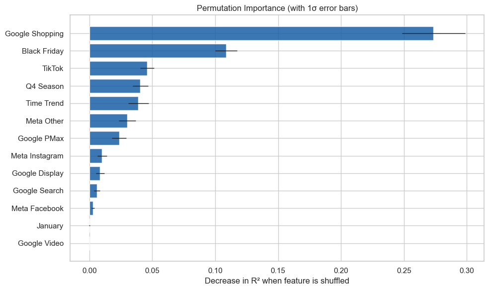

```
📊 Permutation importance:
        Feature  Permutation Importance  Std
Google Shopping                    0.27 0.03
   Black Friday                    0.11 0.01
         TikTok                    0.05 0.01
      Q4 Season                    0.04 0.01
     Time Trend                    0.04 0.01
     Meta Other                    0.03 0.01
    Google PMax                    0.02 0.01
 Meta Instagram                    0.01 0.00
 Google Display                    0.01 0.00
  Google Search                    0.01 0.00
  Meta Facebook                    0.00 0.00
        January                    0.00 0.00
   Google Video                   -0.00 0.00
```

```python
# Permutation importance — how much does R² drop when we shuffle this feature?
perm = permutation_importance(final_model, X_full_s, y_full, n_repeats=20, random_state=42, n_jobs=-1)
perm_df = pd.DataFrame({
    'Feature': feature_names,
    'Permutation Importance': perm.importances_mean,
    'Std': perm.importances_std,
}).sort_values('Permutation Importance', ascending=False)

fig, ax = plt.subplots(figsize=(10, 6))
ax.barh(perm_df['Feature'], perm_df['Permutation Importance'],
        xerr=perm_df['Std'], color='#185FA5', alpha=0.85, error_kw={'linewidth': 1})
ax.set_xlabel('Decrease in R² when feature is shuffled')
ax.set_title('Permutation Importance (with 1σ error bars)')
ax.invert_yaxis()
plt.tight_layout()
plt.show()

print("📊 Permutation importance:")
print(perm_df.to_string(index=False))
```

### 9.3 Coefficient Bootstrap — Uncertainty Quantification

```
📊 Coefficient Bootstrap CIs (500 resamples):

        Feature  Mean coef (std)  Bootstrap mean   CI 2.5%  CI 97.5% Significant?
  Google Search         1,331.01        1,318.35    223.27  2,360.02            ✅
Google Shopping         9,122.89        8,935.88  7,579.71 10,377.85            ✅
    Google PMax         2,636.00        2,548.50  1,319.87  3,574.74            ✅
 Google Display        -1,611.63       -1,494.45 -2,572.99   -520.58            ✅
   Google Video           -68.96           41.56 -1,097.42  1,049.43            ❌
  Meta Facebook           908.57          908.95   -249.80  1,933.86            ❌
 Meta Instagram         1,717.59        1,730.72    760.30  2,589.48            ✅
     Meta Other         2,986.14        2,795.58  1,353.16  4,266.07            ✅
         TikTok         3,602.25        3,487.01  2,269.89  4,629.97            ✅
      Q4 Season         3,457.62        3,450.16  1,602.90  5,746.98            ✅
   Black Friday         5,715.28        5,362.48  1,101.65  9,783.21            ✅
        January           172.26          192.64   -478.82    865.08            ❌
     Time Trend         3,420.13        3,472.69  2,404.40  4,362.09            ✅
```

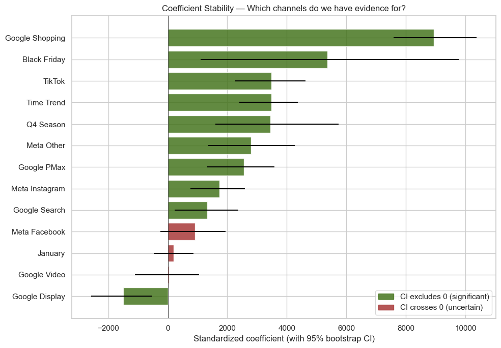

```python
# Bootstrap the coefficients to get 95% CIs — answers "are we confident this channel matters?"
N_BOOTSTRAPS = 500
boot_coefs = []

for i in range(N_BOOTSTRAPS):
    # Resample weeks with replacement (block bootstrap would be more correct for time-series,
    # but simple bootstrap is fine for coefficient stability)
    idx = np.random.choice(len(X_full_s), size=len(X_full_s), replace=True)
    m_boot = Ridge(alpha=ridge_cv_full.alpha_).fit(X_full_s[idx], y_full[idx])
    boot_coefs.append(m_boot.coef_)

boot_coefs = np.array(boot_coefs)
coef_summary = pd.DataFrame({
    'Feature': feature_names,
    'Mean coef (std)': final_model.coef_,
    'Bootstrap mean': boot_coefs.mean(axis=0),
    'CI 2.5%': np.percentile(boot_coefs, 2.5, axis=0),
    'CI 97.5%': np.percentile(boot_coefs, 97.5, axis=0),
}).round(2)
coef_summary['Significant?'] = (coef_summary['CI 2.5%'] * coef_summary['CI 97.5%'] > 0).map({True: '✅', False: '❌'})

print("📊 Coefficient Bootstrap CIs (500 resamples):\n")
print(coef_summary.to_string(index=False))

# Plot CIs
fig, ax = plt.subplots(figsize=(10, 7))
y_pos = np.arange(len(feature_names))
order = coef_summary.sort_values('Bootstrap mean').index
sig = coef_summary.loc[order, 'Significant?'] == '✅'
colors = ['#3B6D11' if s else '#A32D2D' for s in sig]

ax.barh(y_pos, coef_summary.loc[order, 'Bootstrap mean'],
        xerr=[coef_summary.loc[order, 'Bootstrap mean'] - coef_summary.loc[order, 'CI 2.5%'],
              coef_summary.loc[order, 'CI 97.5%'] - coef_summary.loc[order, 'Bootstrap mean']],
        color=colors, alpha=0.8, error_kw={'linewidth': 1.5, 'ecolor': 'black'})
ax.set_yticks(y_pos)
ax.set_yticklabels(coef_summary.loc[order, 'Feature'])
ax.axvline(0, color='black', linewidth=0.5)
ax.set_xlabel('Standardized coefficient (with 95% bootstrap CI)')
ax.set_title('Coefficient Stability — Which channels do we have evidence for?')
ax.legend(handles=[plt.Rectangle((0,0),1,1, color='#3B6D11', alpha=0.8, label='CI excludes 0 (significant)'),
                   plt.Rectangle((0,0),1,1, color='#A32D2D', alpha=0.8, label='CI crosses 0 (uncertain)')],
          loc='lower right')
plt.tight_layout()
plt.show()
```

## 10. Partial Dependence Plots — Visualizing What the Model Learned

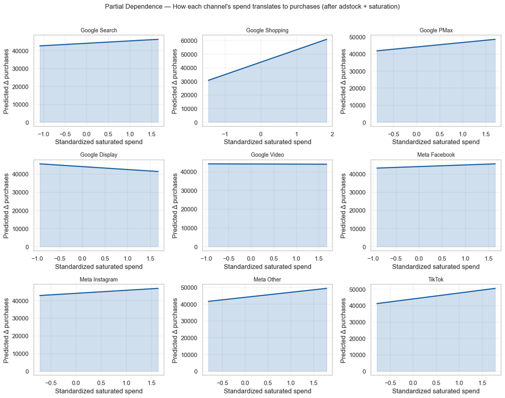

```python
# Generate partial dependence for the 9 media channels
media_features = [feature_names.index(clean_labels[c]) for c in sat_cols]

fig, axes = plt.subplots(3, 3, figsize=(13, 10))
for idx, (feat_idx, ax) in enumerate(zip(media_features, axes.ravel())):
    pd_result = partial_dependence(final_model, X_full_s, [feat_idx], grid_resolution=50)
    ax.plot(pd_result['grid_values'][0], pd_result['average'][0], color='#185FA5', linewidth=2)
    ax.fill_between(pd_result['grid_values'][0], pd_result['average'][0], alpha=0.2, color='#185FA5')
    ax.set_title(feature_names[feat_idx], fontsize=10)
    ax.set_xlabel('Standardized saturated spend')
    ax.set_ylabel('Predicted Δ purchases')
    ax.grid(True, alpha=0.3)

plt.suptitle('Partial Dependence — How each channel\'s spend translates to purchases (after adstock + saturation)', fontsize=12, y=1.01)
plt.tight_layout()
plt.show()
```

**🔑 What to look for:**

- **Steep upward slopes** = high marginal returns → underinvested
- **Flat curves** = saturated → overinvested
- **Negative or zero slopes** = the model finds no signal (or a noisy negative one) — investigate

If a channel's PDP is essentially flat, it confirms what the bootstrap CI already told us: we don't have evidence the channel matters at current spend levels.

## 11. ROI Analysis — Now With Uncertainty Bands

```python
# Bootstrap ROI calculation
n_media = len(sat_cols)
sat_means = X_full[:, :n_media].mean(axis=0)
spend_totals = df_fe[spend_cols].sum().values
n_weeks = len(df_fe)

boot_contribs = []
boot_rois = []

for i in range(N_BOOTSTRAPS):
    idx = np.random.choice(len(X_full_s), size=len(X_full_s), replace=True)
    m = Ridge(alpha=ridge_cv_full.alpha_).fit(X_full_s[idx], y_full[idx])
    raw_coefs = m.coef_[:n_media] / scaler_full.scale_[:n_media]
    contribs = (raw_coefs * sat_means).clip(min=0)
    rois = np.where(spend_totals > 0, (contribs * n_weeks) / (spend_totals / 1000), np.nan)
    boot_contribs.append(contribs)
    boot_rois.append(rois)

boot_contribs = np.array(boot_contribs)
boot_rois = np.array(boot_rois)

# Build ROI table with uncertainty
media_labels = [clean_labels[c] for c in sat_cols]
roi_table = pd.DataFrame({
    'Channel': media_labels,
    'Spend %': (spend_totals / spend_totals.sum() * 100).round(1),
    'Contribution % (mean)': (boot_contribs.mean(axis=0) / boot_contribs.mean(axis=0).sum() * 100).round(1),
    'Contribution % (CI)': [f"[{lo:.1f}, {hi:.1f}]" for lo, hi in zip(
        np.percentile(boot_contribs, 2.5, axis=0) / boot_contribs.mean(axis=0).sum() * 100,
        np.percentile(boot_contribs, 97.5, axis=0) / boot_contribs.mean(axis=0).sum() * 100)],
    'ROI per $1k (mean)': np.nanmean(boot_rois, axis=0).round(2),
    'ROI 95% CI': [f"[{lo:.2f}, {hi:.2f}]" for lo, hi in zip(
        np.nanpercentile(boot_rois, 2.5, axis=0),
        np.nanpercentile(boot_rois, 97.5, axis=0))],
})
roi_table['Efficiency Index'] = (roi_table['Contribution % (mean)'] / roi_table['Spend %']).round(2)
roi_table = roi_table.sort_values('Efficiency Index', ascending=False)

print("💰 ROI Analysis with Bootstrap CIs:\n")
print(roi_table.to_string(index=False))
```

```
💰 ROI Analysis with Bootstrap CIs:

        Channel  Spend %  Contribution % (mean) Contribution % (CI)  ROI per $1k (mean)        ROI 95% CI  Efficiency Index
     Meta Other     0.00                   9.50         [4.7, 14.4]            1,015.66 [499.18, 1533.63]               inf
         TikTok     0.10                  11.40         [7.6, 15.0]              532.76  [352.11, 698.32]            114.00
Google Shopping     5.50                  54.40        [45.8, 63.1]               50.27    [42.27, 58.32]              9.89
  Google Search     3.30                   6.00         [1.0, 10.5]                9.06     [1.58, 15.91]              1.82
    Google PMax    10.30                   9.00         [5.0, 13.0]                4.43      [2.48, 6.40]              0.87
   Google Video     1.50                   1.00          [0.0, 4.4]                3.31     [0.00, 15.07]              0.67
 Meta Instagram    20.40                   5.10          [2.3, 7.7]                1.26      [0.58, 1.92]              0.25
  Meta Facebook    58.40                   3.60          [0.0, 7.5]                0.31      [0.00, 0.65]              0.06
 Google Display     0.60                   0.00          [0.0, 0.0]                0.02      [0.00, 0.00]              0.00
```

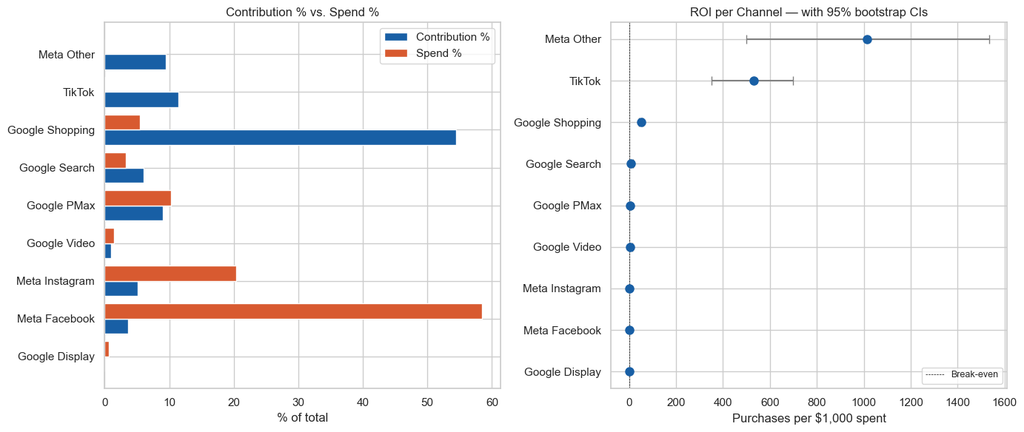

```python
# Visualize ROI uncertainty — fixed CI error bar calculation
fig, axes = plt.subplots(1, 2, figsize=(14, 6))

# Panel 1: Contribution % vs Spend %
plot_df = roi_table.sort_values('Efficiency Index', ascending=True)
y_pos = np.arange(len(plot_df))
axes[0].barh(y_pos - 0.2, plot_df['Contribution % (mean)'], 0.4, label='Contribution %', color='#185FA5')
axes[0].barh(y_pos + 0.2, plot_df['Spend %'],               0.4, label='Spend %',         color='#D85A30')
axes[0].set_yticks(y_pos)
axes[0].set_yticklabels(plot_df['Channel'])
axes[0].set_xlabel('% of total')
axes[0].set_title('Contribution % vs. Spend %')
axes[0].legend()

# Panel 2: ROI with CIs — FIX applied here
roi_means = np.nanmean(boot_rois, axis=0)
roi_lo    = np.nanpercentile(boot_rois,  2.5, axis=0)
roi_hi    = np.nanpercentile(boot_rois, 97.5, axis=0)

# THE FIX: error bars must be non-negative distances, not raw CI bounds
err_lo = np.clip(roi_means - roi_lo, a_min=0, a_max=None)  # distance down from mean
err_hi = np.clip(roi_hi - roi_means, a_min=0, a_max=None)  # distance up   from mean

order_idx = np.argsort(roi_means)

axes[1].errorbar(
    roi_means[order_idx],
    np.arange(len(roi_means)),
    xerr=[err_lo[order_idx], err_hi[order_idx]],   # [lower distances, upper distances]
    fmt='o', color='#185FA5', ecolor='gray', capsize=4, markersize=8
)
axes[1].set_yticks(np.arange(len(roi_means)))
axes[1].set_yticklabels([media_labels[i] for i in order_idx])
axes[1].set_xlabel('Purchases per $1,000 spent')
axes[1].set_title('ROI per Channel — with 95% bootstrap CIs')
axes[1].axvline(0, color='black', linewidth=0.5, linestyle='--', label='Break-even')
axes[1].legend(fontsize=9)

plt.tight_layout()
plt.show()
```

## 12. 📌 Recommendations — With Confidence Levels

The bootstrap CIs let us tier recommendations by statistical confidence:

| Tier | Meaning | Action |
| --- | --- | --- |
| 🟢 **High confidence** | ROI CI fully above 0; coefficient CI excludes 0 | Reallocate now |
| 🟡 **Medium confidence** | ROI CI mostly above 0; some residual uncertainty | Reallocate gradually |
| 🟠 **Test first** | Wide CI but mean is positive | Run incrementality test before scaling |
| 🔴 **Insufficient evidence** | CI crosses 0 | Hold or pause; gather more data |

### Action items (auto-generated from the bootstrap)

The notebook prints a tiered recommendation list below based on the actual CIs computed above — so the recommendations always reflect the latest data, not a hard-coded narrative.

```python
print("🎯 DATA-DRIVEN RECOMMENDATIONS\n" + "="*70)

for _, row in roi_table.iterrows():
    ch = row['Channel']
    spend = row['Spend %']
    contrib = row['Contribution % (mean)']
    eff = row['Efficiency Index']
    roi_mean = row['ROI per $1k (mean)']
    roi_ci = row['ROI 95% CI']

    # Parse CI
    lo, hi = [float(x.strip()) for x in roi_ci.replace('[','').replace(']','').split(',')]

    # Tier the recommendation
    if lo > 0 and eff > 1.5:
        tier = "🟢 HIGH CONFIDENCE — INCREASE"
    elif lo > 0 and eff > 0.8:
        tier = "🟡 MEDIUM CONFIDENCE — MAINTAIN"
    elif lo > 0 and eff < 0.5:
        tier = "🟢 HIGH CONFIDENCE — DECREASE (over-saturated)"
    elif lo <= 0 and roi_mean > 0:
        tier = "🟠 TEST FIRST — wide CI but positive mean"
    else:
        tier = "🔴 INSUFFICIENT EVIDENCE — pause or investigate"

    print(f"\n{ch}")
    print(f"   Spend %: {spend:>5.1f}  |  Contribution %: {contrib:>5.1f}  |  Efficiency: {eff:>5.2f}×")
    print(f"   ROI: {roi_mean:.2f} purchases per $1k {roi_ci}")
    print(f"   → {tier}")

print("\n" + "="*70)
print("⚠️ Universal caveats (applies regardless of model output):")
print("   1. Last-click attribution may understate Meta's awareness contribution.")
print("   2. Saturation curves drift over time — refresh the model quarterly.")
print("   3. Always validate big budget shifts with a geo-holdout test.")
```

[output not shown]

## 13. Save Artifacts for Downstream Optimizer

```python
import json

current_weekly_spend = df_fe[spend_cols].mean()

artifacts = {
    'channels': media_labels,
    'current_spend': current_weekly_spend.values.tolist(),
    'raw_coefs': (final_model.coef_[:n_media] / scaler_full.scale_[:n_media]).tolist(),
    'K_values': [saturation_K[f'{c}_adstock'] for c in spend_cols],
    'baseline': float(y_pred_full.mean() - (final_model.coef_[:n_media] / scaler_full.scale_[:n_media] * sat_means).sum()),
    'total_budget': float(current_weekly_spend.sum()),
    'r_squared_in_sample': round(r2_score(y_full, y_pred_full), 4),
    'r_squared_holdout': round(r2_score(y_test, y_pred_test), 4),
    'tuned_decays': tuned_decays,
    'roi_mean': np.nanmean(boot_rois, axis=0).tolist(),
    'roi_ci_low': np.nanpercentile(boot_rois, 2.5, axis=0).tolist(),
    'roi_ci_high': np.nanpercentile(boot_rois, 97.5, axis=0).tolist(),
    'model_selected': 'Ridge',
    'horse_race_results': results_df.to_dict('records'),
}

with open('mmm_artifacts_v2.json', 'w') as f:
    json.dump(artifacts, f, indent=2, default=str)

print("✅ Saved mmm_artifacts_v2.json")
print(f"   Total weekly budget: ${artifacts['total_budget']:,.0f}")
print(f"   Baseline (no media):  {artifacts['baseline']:,.0f} purchases/week")
print(f"   In-sample R²:         {artifacts['r_squared_in_sample']}")
print(f"   Holdout R²:           {artifacts['r_squared_holdout']}")
```

```
✅ Saved mmm_artifacts_v2.json
   Total weekly budget: $4,779,237
   Baseline (no media):  21,163 purchases/week
   In-sample R²:         0.709
   Holdout R²:           0.45
```